# Predictive Modeling Process

November 4, 2016

## Introduction

- In this project, we will recreate the predictive modeling process in Chapter 6: Linear Model Selection and Regularization of the book [**An Introduction to Statistical Learning**](http://www-bcf.usc.edu/~gareth/ISL/).
- We will be using multiple regression models on the *Credit* dataset and compare the differences between these models.

## Data

- Variables
  - Predictor Variables
    - quantitative: age, cards, income, limit, education, and rating
    - qualitative: gender, student, status, ethnicity
  - Response Variable
    - quantitative: balance

## Pre-Modeling Data Processing

There are two major processing steps we took to prepare the data:

- Dummy out categorical variables
  - Transforming categorical variable into dummy variables

    ```
    temp_credit <- model.matrix(Balance ~ ., data = credit)
    new_credit <- cbind(temp_credit[ ,-1], Balance = credit$Balance)
    ```

- Mean centering and standardizing
  - each variable will have mean zero, and standard deviation one to have comparable scales

    ```
    scaled_credit <- scale(new_credit, center = TRUE, scale = TRUE)
    ```

## Preparing Training and Testing Data

In order to evaluate the models, we will take a random sample of the data for model building and use the rest to understand the model performance.

- **training set**: generate a random sample of size 300. Use sample() function and an integer vector 1:400 to sample 300 values
- **testing set**: rest of 100 observations not included in the train set

## Regression Models

- Ordinary Least Squares Regression (OLS)
- Shrinkage Methods
  - Ridge Regression
  - Lasso Regression
- Dimension Reduction Methods
  - Principal Components Regression (PCR)
  - Partial Least Squares Regression (PLSR)

## OLS

- Minimizing the RSS in order to minimize the error of the prediction

## Ridge Regression

- Shrinkage method
- Add a tuing parameter based on OLS
- Flexibility of ridge regression decreases with increases in tuning parameter

\[RSS + \lambda\sum_{j=1}^{p}\beta_j^{2}\]

## Lasso Regression

- Shinkage method
- Will result in estimations of coefficients to zero

\[\sum_{i=1}^{n}(y_i-\beta_0-\sum_{j=1}^{p}\beta_jx_{ij})^2+\lambda\sum_{j=1}^{p}|\beta_j|\]

## PCR

PCR is a dimension reduction technique for regression that involves constructing the first \(M\) principal components, \(Z_1 + \dots + Z_{M*}\), and then using these components as the predictors in a linear regression model that is fit using least squares.

## PLSR

- An extension of PCR

\[Z_1=\sum_{j=1}^p\phi_{j1}X_j\]

## Analysis

## OLS

- Benchmark for comparison
- Education, Gender, Martial Status and Ethnicity has big p-value， thus not statitiscally significant.
- Income, Limit, and Rating have large and statistically significant coefficients.

## Ridge

- The smallest validation error is \(\lambda\) = 0.01.
- Small \(\lambda\)
- Similar coefficients with OLS, expect the larger Rating coefficients.

## Ridge

This is the image for ridge cross validation errors.

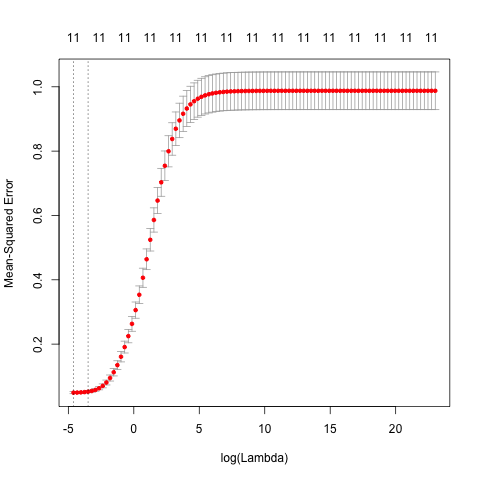

## Lasso

The graph for lasso cross-validation errors:

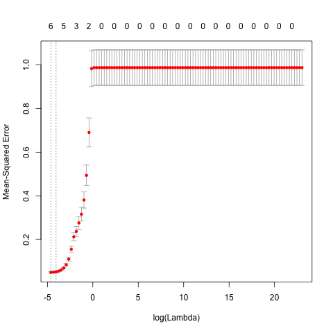

## PCR

- The best M is 11.
- Almost same coefficients with OLS and PLSR.
- Coefficients also similar to Ridge and Lasso.

## PCR

This is the MSE plot for PCR:

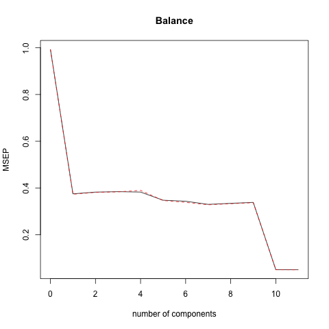

## PLSR

- The best M is 10.
- Almost same to OLS and PCR.
- Similar to Ridge.

## PLSR

This is the MSE plot for PLSR:

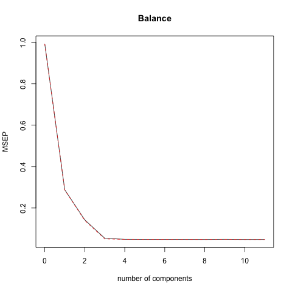

## Results

This is the table for MSE of all regression models:

MSE of Five Regression Methods

| names | mse |
| --- | --- |
| ols | 0.0447862 |
| ridge | 0.0479811 |
| lasso | 0.0515181 |
| pcr | 0.0474722 |
| plsr | 0.0475391 |

## MSE

- Close to one another
- lasso has the largest MSE 0.0515181, ols the least 0.0447862
- ols the best fit model, lasso the worst fit model

## Results

This the trendline plot for each type of regression models fit on Credit.csv:

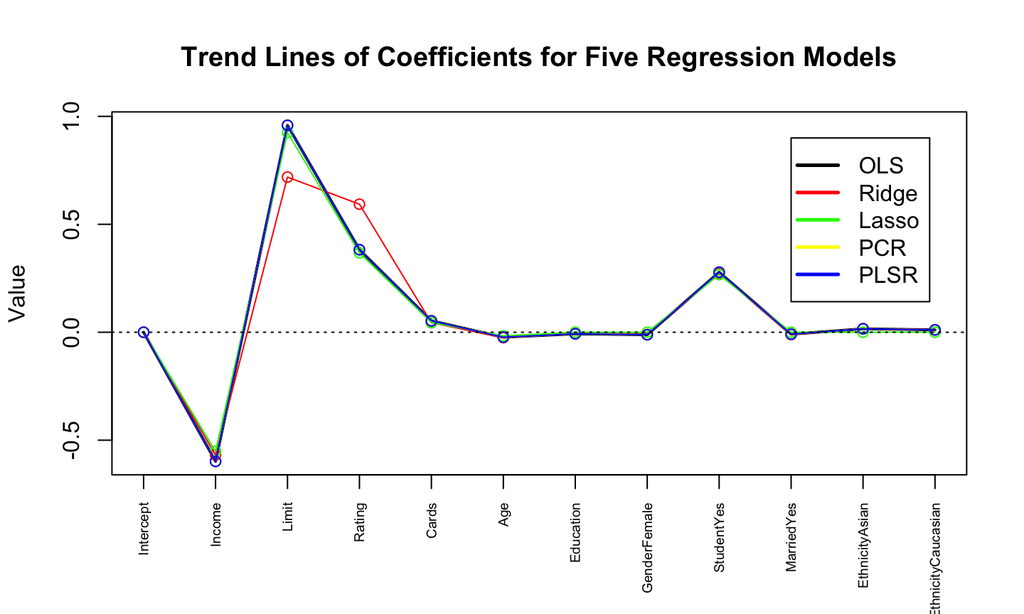

## Conclusions

- OLS is the best fit model to Credit dataset.
- Income, Limit, and Rating are statistically and economiclly significant across five models.
- Lasso is the worst fit model to Credit dataset.